# STAT 118: Notes M

Simple Linear Regression

Author

Affiliation

Emily Malcolm-White

Middlebury College

```r
#LOAD PACKAGES
library(tidyverse)
library(scales)

#LOAD DATA
housingdata <- read.csv("https://raw.githubusercontent.com/abhiram-ds/housing_price_adv_regression/main/train.csv")
```

The data comes from [Kaggle](https://www.kaggle.com/c/house-prices-advanced-regression-techniques/data?select=train.csv). It describing the sale of individual residential property in Ames, Iowa from 2006 to 2010.

# Motivation

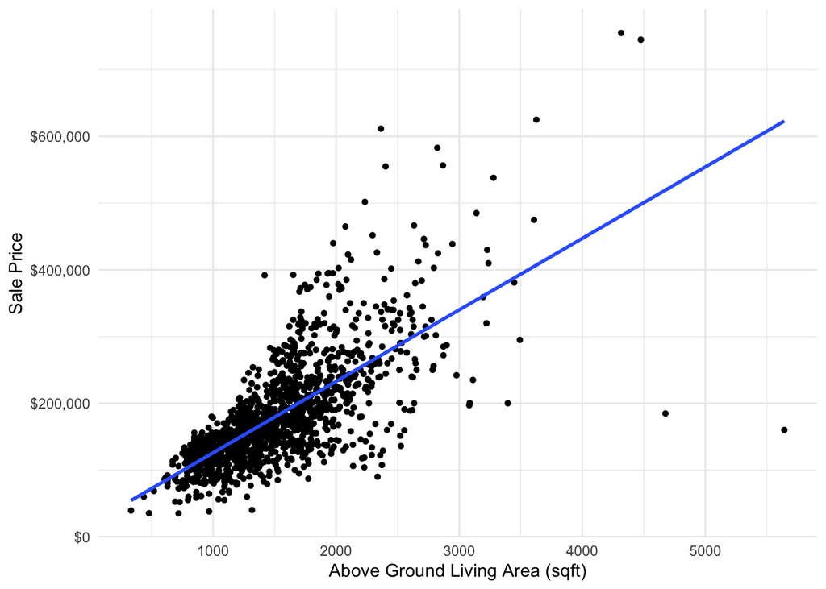

```r
housingdata %>%
  ggplot(aes(x=GrLivArea, y=SalePrice)) +
  geom_point(pch=16) +
  geom_smooth(method=lm, se=FALSE) +
  scale_y_continuous(labels = dollar_format(prefix="$")) +
  labs(x = "Above Ground Living Area (sqft)", y = "Sale Price") +
  theme_minimal()
```

# Correlation

Correlation always takes on values between -1 and 1, describes the strength of the linear relationship between two variables.

[figure not shown]

```r
cor(housingdata$GrLivArea, housingdata$SalePrice)
```

```
[1] 0.7086245
```

# Correlation Does Not Imply Causation

[figure not shown]

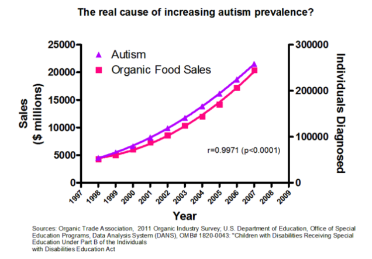

[figure not shown]

## Could be:

- Random coincidence
- Reverse causality
- Confounding variable

# Equations and Interpretation of Coefficients

Want to fit a linear model:

$$\hat{y} = b_0 + b_1x$$

To fit a linear regression model we need the `lm()` function.

```r
#lm(dependent_variable ~ independent_variable, data = dataset)
lm(SalePrice ~ GrLivArea, data=housingdata)
```

```
Call:
lm(formula = SalePrice ~ GrLivArea, data = housingdata)

Coefficients:
(Intercept)    GrLivArea
    18569.0        107.1
```

```r
#OR

lm(SalePrice ~ GrLivArea, data=housingdata) %>%
  summary()
```

```
Call:
lm(formula = SalePrice ~ GrLivArea, data = housingdata)

Residuals:
    Min      1Q  Median      3Q     Max
-462999  -29800   -1124   21957  339832

Coefficients:
             Estimate Std. Error t value Pr(>|t|)
(Intercept) 18569.026   4480.755   4.144 3.61e-05 ***
GrLivArea     107.130      2.794  38.348  < 2e-16 ***
---
Signif. codes:  0 '***' 0.001 '**' 0.01 '*' 0.05 '.' 0.1 ' ' 1

Residual standard error: 56070 on 1458 degrees of freedom
Multiple R-squared:  0.5021,    Adjusted R-squared:  0.5018
F-statistic:  1471 on 1 and 1458 DF,  p-value: < 2.2e-16
```

# Tidy it up with `broom`

[figure not shown]

```r
library(broom)
library(kableExtra)

#prettier
lm(SalePrice ~ GrLivArea, data=housingdata) %>%
  tidy() %>%
  kbl() %>%
  kable_styling()
```

| term | estimate | std.error | statistic | p.value |
| --- | --- | --- | --- | --- |
| (Intercept) | 18569.0259 | 4480.754549 | 4.144174 | 3.61e-05 |
| GrLivArea | 107.1304 | 2.793621 | 38.348207 | 0.00e+00 |

To interpret the y-intercept coefficient ($b_0$):

- When `x` is 0, we predict `y` to be $b_0$.
- In this case, when a house has NO above ground square footage, we predict it will cost $18,569.

**Tip**

Note that the interpretation of the y-intercept doesn’t always make sense.

In this case, what does it mean for a house to have no above ground square footage? Is it only a basement? Only a plot of land with no house?

To interpret the slope coefficient ($b_1$):

- For every 1 unit increase in `x`, we expect a $b_1$ unit increase in `y`, on average.
- In this case, for every 1 additional square foot above ground in a house, we expect an $107 increase in the sales price of the house.

# Assumptions, Residuals, and Residual Plots

## Assumptions of Linear Regression:

- **Linearity:** The relationship between X and the mean of Y is linear – look at scatterplot
- **Homoscedasticity:** The variance of residual is the same for any value of X – look at fitted vs. residuals plot
- **Independence:** Observations are independent of each other – think about context
- **Normality:** For any fixed value of X, Y is normally distributed. – check the QQ plot

## Check the scatterplot

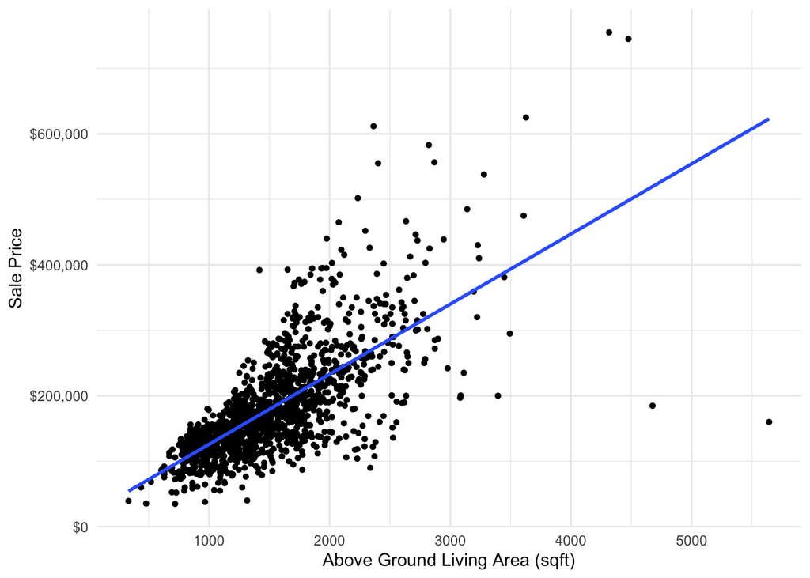

```r
housingdata %>%
  ggplot(aes(x=GrLivArea, y=SalePrice)) +
  geom_point(pch=16) +
  geom_smooth(method=lm, se=FALSE) +
  scale_y_continuous(labels = dollar_format(prefix="$")) +
  labs(x = "Above Ground Living Area (sqft)", y = "Sale Price") +
  theme_minimal()
```

Some examples of nonlinear plots:

[figure not shown]

Credit: chartio

## fitted vs. residuals plot and QQplots

```r
# save our lm() as fit
fit <- lm(SalePrice ~ GrLivArea, data=housingdata)
```

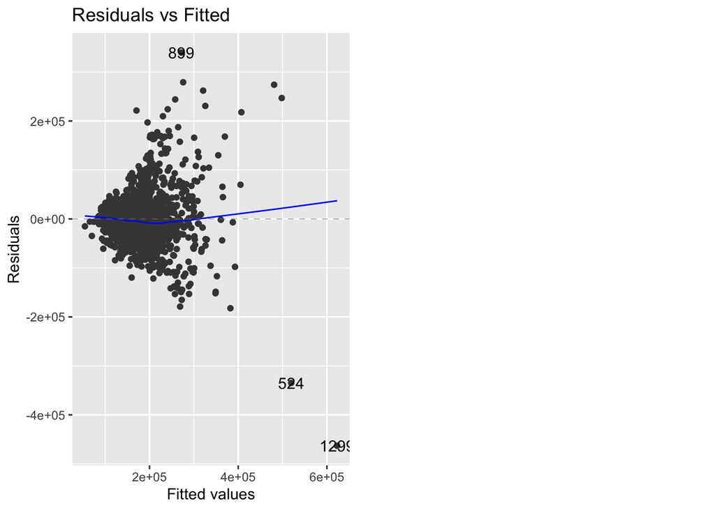

```r
library(ggfortify)
autoplot(fit, which=1)
```

Some other examples:

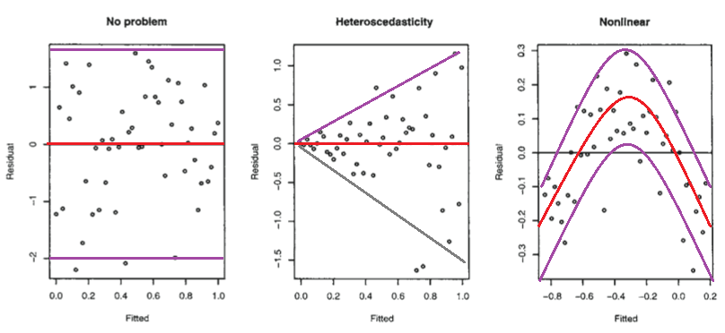

## QQ plot

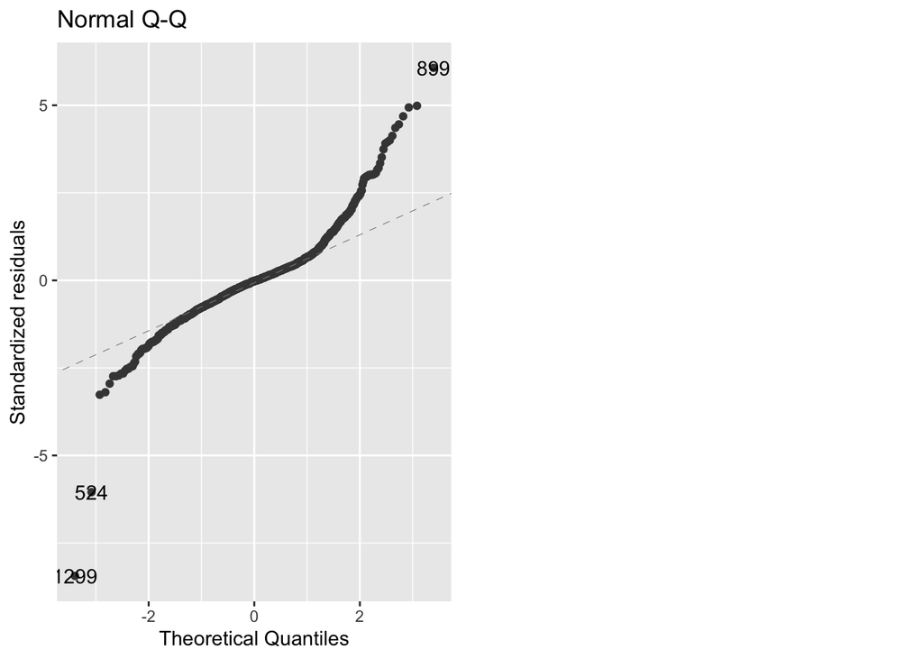

```r
autoplot(fit, which=2)
```

Some other examples:

[figure not shown]

# Prediction

```r
newdata <- data.frame(GrLivArea = c(2000))
predict(fit, newdata)
```

```
       1
232829.7
```

## Interpolation vs. Extrapolation

**Interpolation** is a method of estimating a hypothetical value that exists within a data set.

**Extrapolation** is a method of estimation for hypothetical values that fall outside a data set.

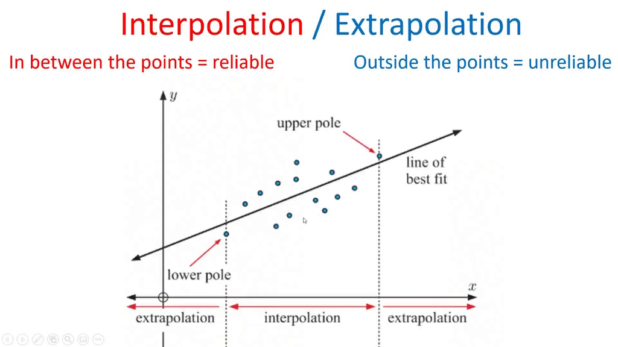